# Exploring Number of Words and Other Characteristics of Messages Received

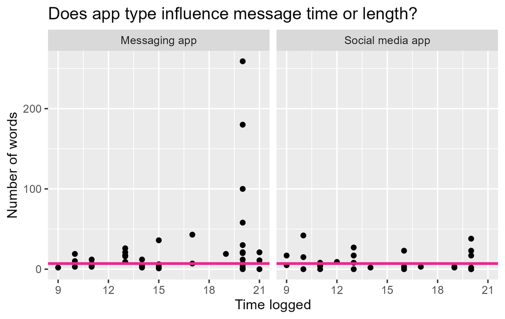

Plot 1

Messages sent on messaging apps seem to be longer than those sent on social media apps, after 3pm. There are small peaks in the number of words in a message at around 10am, 1pm and after dinner, this make sense as it is time when people are likely to either be on a break or not at work/school.

[figure not shown]

Second plot

Messages sent by regular contacts seem to have more variance compared to those from non-regular contacts, with lots of 0 word messages, and a some very long messages.The longest messages were received by regular contacts at night, which makes sense as people are likely to be off work/school and may have time to do things like tell stories at night. There are a large number of zero word messages sent by regular contacts and none by non-regular contacts, this makes sense as people you don’t usually talk to generally need to give context or an explanation as to why they are sending something even if they are sending a post, while memes and posts being sent by friends often doesn’t need any text accompanying it.

## Counts of various message lengths compared to the median number of words in a message

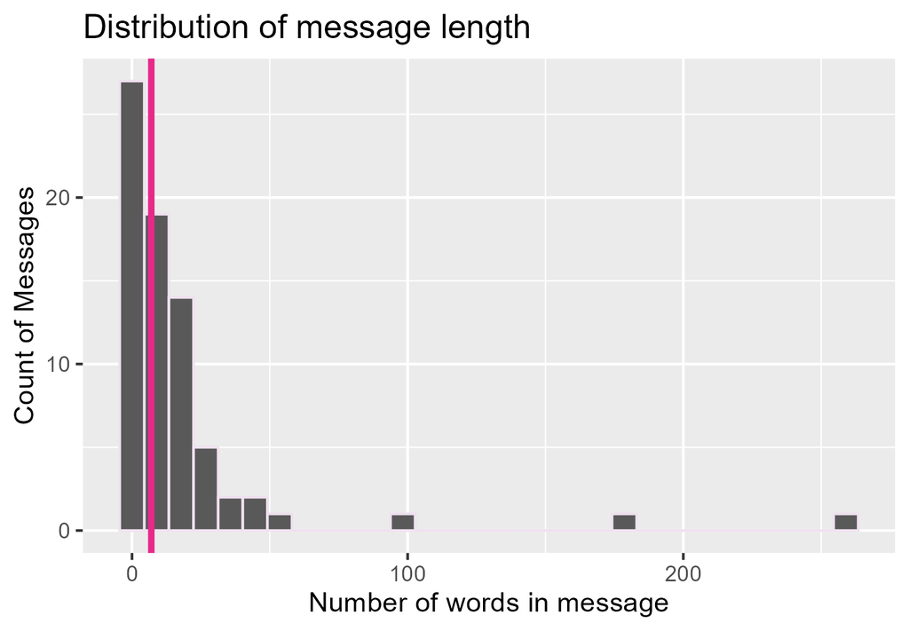

Third plot

The median number of messages is close to zero. There are much higher counts of short messages (under 30ish words) than longer messages, which makes sense as messaging is usually a short form of contacting someone, and things that take more words to communicate may either be sent as an email or be a phone call. There are three messages of over 90 words. These are likely either stories of rants.

## Number of words in a message for regular and non-regular contacts and some key summary stats

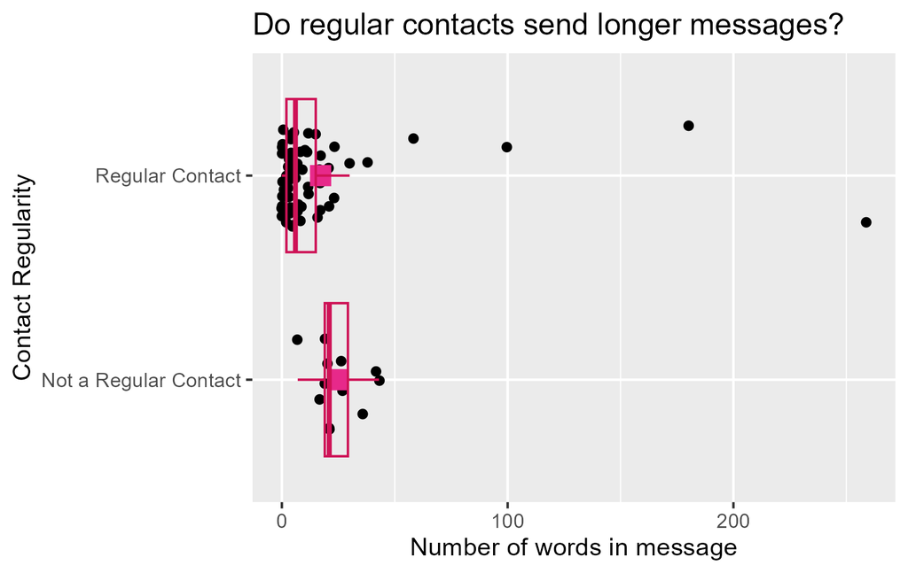

Fourth plot